# Exploratory and Confirmatory Factor Anaysis

# Activity: Holzinger and Swineford Factor Analysis

The classic Holzinger and Swineford (1939) study of mental ability consists of mental ability test scores of seventh- and eighth-grade children from two different schools (Pasteur and Grant-White).

In the original dataset, there are scores for 26 tests. However, a smaller subset with 9 variables is more widely used in the literature (for example in Joreskog’s 1969 paper, which also uses the 145 subjects from the Grant-White school only). These mental abilities are:

x1 Visual perception

x2 Cubes

x3 Lozenges

x4 Paragraph comprehension

x5 Sentence completion

x6 Word meaning

x7 Speeded addition

x8 Speeded counting of dots

x9 Speeded discrimination straight and curved capitals

Holzinger and Swineford thought that these abilities could be condensed into three latent abilities for visual skill, writing skill, and math skill:

Visual skill was hypothesized as a combination of x1, x2, and x3

Writing skill was hypothesized as a combination of x4, x5, and x6

Math skill was hypothesized as a combination of x7, x8, and x9

The CFA model looks like this:

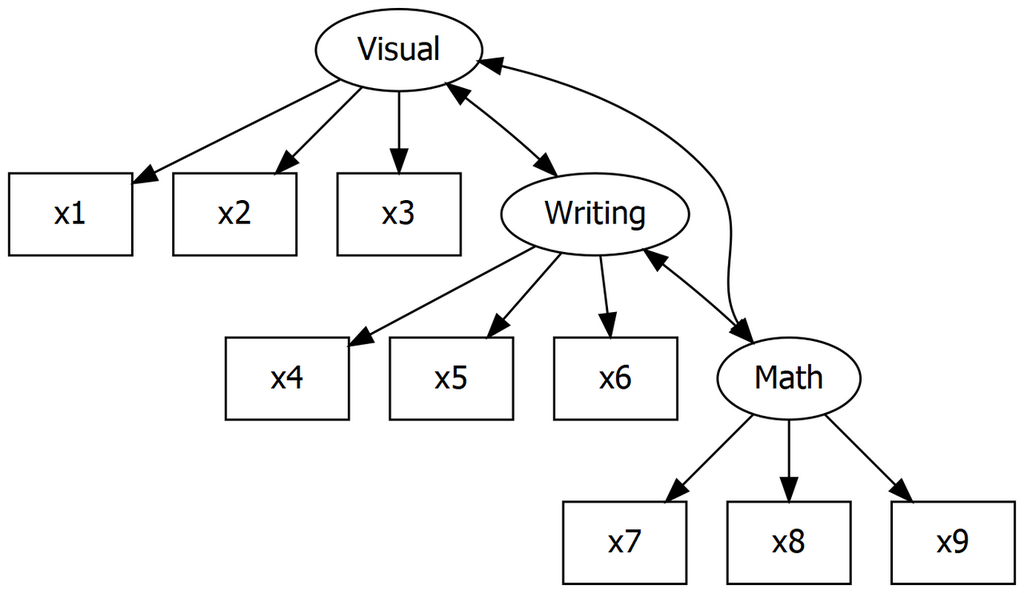

Holzinger and Swineford Model of Mental Ability

## Load data

Luckily, the Holzinger and Swineford dataset is a practice dataset contained in the lavaan package for CFA, so we don;t need to load it from the computer, we can load it from the package. Lets do that now:

```r
mental <- lavaan::HolzingerSwineford1939
head(mental)
```

|  | id | sex | ageyr | agemo | school | grade | x1 | x2 | x3 | x4 | x5 | x6 | x7 | x8 | x9 |
| --- | --- | --- | --- | --- | --- | --- | --- | --- | --- | --- | --- | --- | --- | --- | --- |
| 1 | 1 | 1 | 13 | 1 | Pasteur | 7 | 3.333333 | 7.75 | 0.375 | 2.333333 | 5.75 | 1.2857143 | 3.391304 | 5.75 | 6.361111 |
| 2 | 2 | 2 | 13 | 7 | Pasteur | 7 | 5.333333 | 5.25 | 2.125 | 1.666667 | 3.00 | 1.2857143 | 3.782609 | 6.25 | 7.916667 |
| 3 | 3 | 2 | 13 | 1 | Pasteur | 7 | 4.500000 | 5.25 | 1.875 | 1.000000 | 1.75 | 0.4285714 | 3.260870 | 3.90 | 4.416667 |
| 4 | 4 | 1 | 13 | 2 | Pasteur | 7 | 5.333333 | 7.75 | 3.000 | 2.666667 | 4.50 | 2.4285714 | 3.000000 | 5.30 | 4.861111 |
| 5 | 5 | 2 | 12 | 2 | Pasteur | 7 | 4.833333 | 4.75 | 0.875 | 2.666667 | 4.00 | 2.5714286 | 3.695652 | 6.30 | 5.916667 |
| 6 | 6 | 2 | 14 | 1 | Pasteur | 7 | 5.333333 | 5.00 | 2.250 | 1.000000 | 3.00 | 0.8571429 | 4.347826 | 6.65 | 7.500000 |

You can see we have some demographic information and then the items that we are going to run CFA with to confirm the factor structure hypothesised by Holzinger and Swineford.

Lets do that now.

## Build the CFA model

Write the script to build the model for three latent variables: visual, writing, and math. Dont forget to specify the latent variables with “=~”. Save the model object as “mental.model”

## Fit the CFA Model

Now write the code to fit the CFA model to the data and save it as a new object called “mental.fit”. Then request the summary estimates:

Summarize the key fit indexes for this model. Are they indicative of adequate fit?

Do the items loading well on their respective latent variables?

How are the factors correlated with each other?

## Visulaise the CFA

Finally, write the code to visualize the CFA model with the standardised estimates plotted. Don’t forget to use semPaths

Nice job!

– This post covers my notes of Exploratory Factor Analysis which draw some help from the book “Discovering Statistics using R (2012)” by Andy Field. Some code and text come from the book. For those parts, credit goes to him.